# Netflix EDA

Yunus Emre Doğan

12/28/2021

## General View of Netflix Content

As we see from below graph there are more than 2 times more Movies than TV Shows on Netflix.

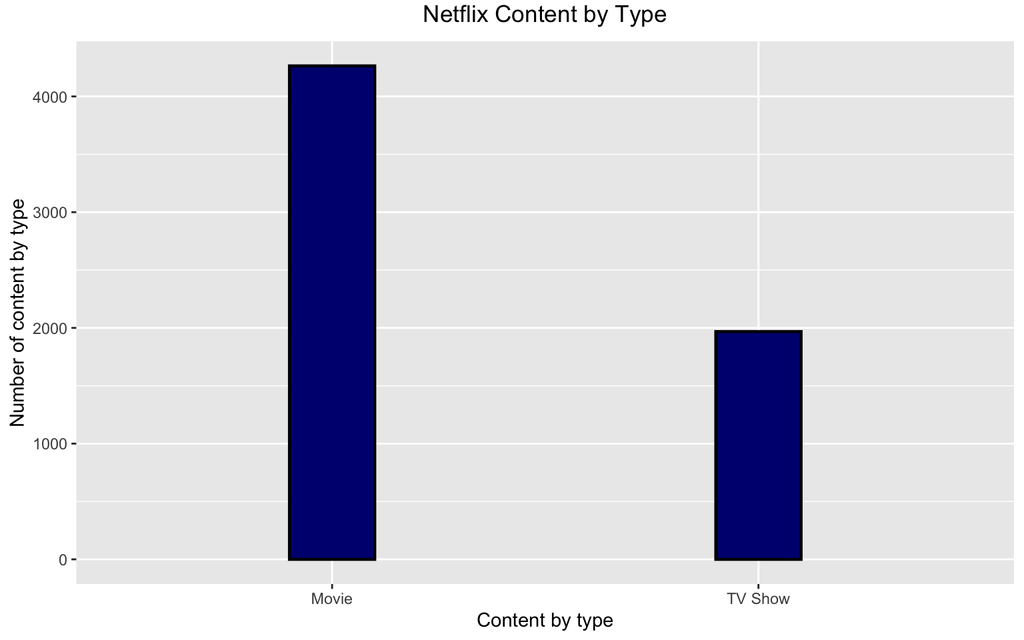

## 10 Most Occurring Cast Members

When we look at cast members, 6 out of 10 most occurring name are Indian names. Moreover 8 out of 10 most occurring names are from Asia. This may be a result of Netflix choosing more from Asian Movies and TV shows to list.

10 Most Occurring Cast Member

| cast | count |
| --- | --- |
| Anupam Kher | 30 |
| Om Puri | 25 |
| Takahiro Sakurai | 24 |
| Shah Rukh Khan | 24 |
| Boman Irani | 23 |
| Andrea Libman | 22 |
| Paresh Rawal | 22 |
| Yuki Kaji | 22 |
| Akshay Kumar | 19 |
| John Cleese | 18 |

## 10 Most Occurring Directors

Contrary to the cast members, it is very obvious that US directors dominates the table.

10 Most Occurring Directors

| Director | count |
| --- | --- |
| Jan Suter | 18 |
| Raúl Campos | 18 |
| Jay Karas | 14 |
| Marcus Raboy | 14 |
| Jay Chapman | 12 |
| Martin Scorsese | 9 |
| Steven Spielberg | 9 |
| David Dhawan | 8 |
| Johnnie To | 8 |
| Lance Bangs | 8 |

## 10 Most Occurring Countries

When we look at the content by the origin country, there is a clear domination by United States as well. Followed by India and United Kingdom, results are not surprising. Netflix is indexing more from the countries which produces and advertises more.

10 Most Occurring Countries

| country | count |
| --- | --- |
| United States | 2302 |
| India | 807 |
| United Kingdom | 483 |
| United States | 308 |
| Canada | 206 |
| Japan | 183 |
| France | 147 |
| South Korea | 146 |
| Spain | 139 |
| France | 124 |

## Content by the Release Year

More than 90% of the Netflix content are current productions. This may stem from different reasons. Netflix could be choosing from current and low copyright price content or stay up to date with current productions.

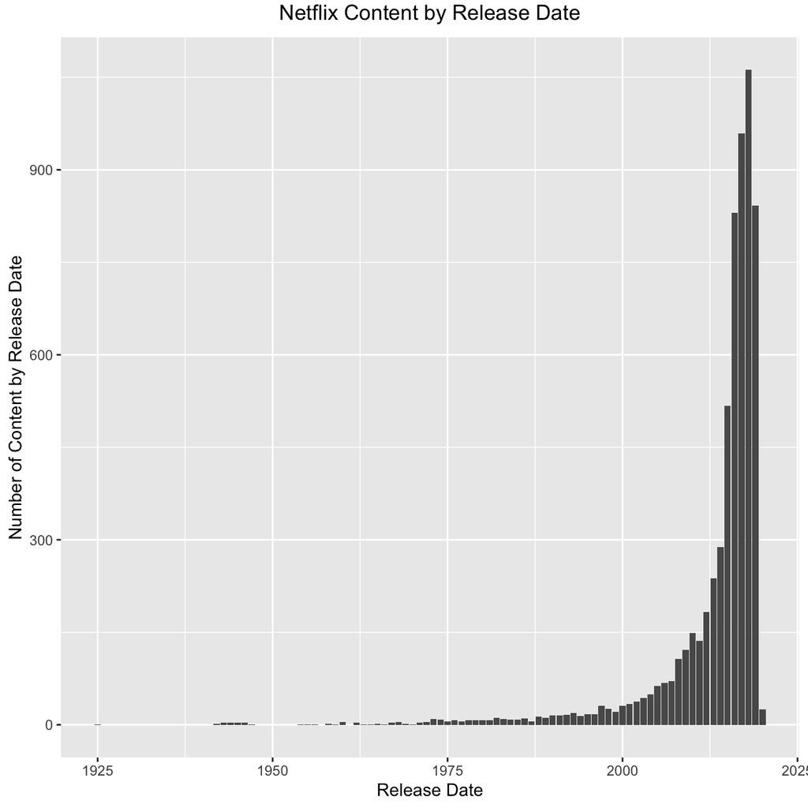

## Distribution of Duration of Movies

Average duration of the movies indexed in Netflix is around 100 minutes.

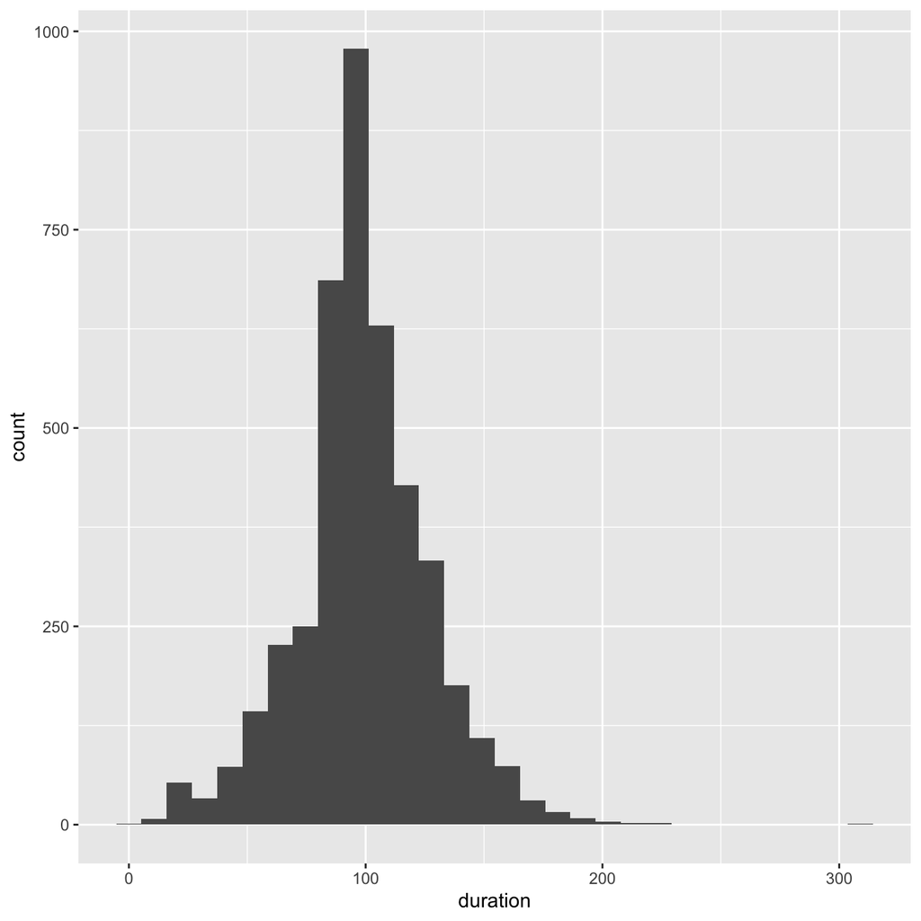

## Netflix Indexing by Year

[figure not shown]

```r
ggplot(date_Added, aes(year_added, count)) +
  geom_bar(width=0.2, colour ="black", size= 0.8, fill = "navy blue", stat="identity") +
  labs(
      x="Year",
      y="Number of Content by Year",
      title="Netflix Content by Year Added") + theme(legend.title=element_blank(),
                                                    plot.title = element_text(hjust = 0.5, vjust = 2))
```